# INESSS

v.1.1.0

2022-05-11

# Support

Pour des questions, des commentaires ou pour désigner tout défaut de conception, écrire un courriel à `guillaume.boucher@inesss.qc.ca` et indiquer l’objet `librairie inesss`.

# Installation de la librairie *inesss*

- Télécharger le fichier *inesss_x.y.z.tar.gz* sur votre poste où *x.y.z* est le numéro de version.
- Copier le code suivant dans la console de RStudio en prenant bien soin d’y inscrire le répertoire complet et le nom du fichier (**ne pas copier l’exemple**).
  - Remplacer les `\` par `/` ou `\\`

```r
if (!"remotes" %in% installed.packages()[,1]) install.packages("remotes")
remotes::install_local("Mon/repertoire/de/telechargement/inesss_x.y.z.tar.gz", upgrade = "never")
```

- Pour avoir accès aux fonctions et aux tables de la librairie :

```r
library(inesss)
```

# Documentation

- **Gabarits et Outils EXCEL :** Fichiers à utiliser pour *Requêtes via Excel* et macros VBA pratiques pour Excel.
- **Vignettes :** Fichiers HTML expliquant la ou les méthodes utilisées pour certaines fonctions de la librairie.
- **AIDE-FORMULAIRE.pdf :** Comment utiliser le formulaire interactif et la section *Requêtes via Excel*. Montre également des exemples de code SQL selon les arguments demandés.
- **AIDE-FORMULAIRE-EXEMPLES-ARGUMENTS.xlsx** : Exemple de document à utiliser dans le formulaire interactif à la section *Requêtes via Excel*.
- **AIDE-FORMULAIRE-EXEMPLES-RESULTATS.xlsx** : Résultats générés à partir du fichier *AIDE-FORMULAIRE-EXEMPLES-ARGUMENTS.xlsx*.
- **inesss_x.y.z :** Documentation complète de la librairie *inesss* où *x.y.z* indique le numéro de version.
- **inesss-REGISTRE-VERSION.html :** Registre des versions. Tous les ajouts et les modifications apportées à la librairie y sont inscrits.

# Démarrer le formulaire

[figure not shown]

# Notes de création

## R

R version 4.0.5 (2021-03-31)

## Librairies

`askpass` v.1.1  
`data.table` v.1.14.0  
`DBI` v.1.1.1  
`fs` v.1.5.0  
`kableExtra` v.1.3.4  
`knitr` v.1.31  
`lubridate` v.1.7.10  
`miniUI` v.0.1.1.1  
`parallel` v.4.0.5  
`odbc` v.1.3.1  
`Rd2md` v.0.0.5  
`readxl` v.1.3.1  
`rmarkdown` v.2.11  
`rstudioapi` v.0.13  
`shiny` v.1.6.0  
`shinydashboard` v.0.7.1  
`shinyFiles` v.0.9.0  
`stringr` v.1.4.0  
`testthat` v.3.0.2  
`writexl` v.1.3.1

# Autres installations/désinstallations

## Installation de R

- Télécharger la version R 4.0.5 en cliquant [ici](https://cloud.r-project.org/bin/windows/base/old/4.0.5/R-4.0.5-win.exe) (ou la dernière version [ici](https://cloud.r-project.org/bin/windows/base/)).
- Ouvrir le fichier téléchargé.
- Choisir la langue utilisée par l’assistant d’installation, puis cliquer sur *OK*.
- **Information** : Une note apparaît indiquant que vous devez avoir les privilèges d’administrateurs. Ignorer cet avertissement et cliquer sur *Suivant*.
- **Information** : Une note sur la licence et les droits d’utilisation de R apparaît. Cliquer sur *Suivant*.
- **Dossier de destination** : Choisir un répertoire où vous avez les droits d’écriture. Le répertoire par défaut `C:\Users\msXXX\Documents\R\R-4.0.5` est un bon choix. Cliquer sur *Suivant*.
- **Composants à installer** : Installer tous les composants. Cliquer sur *Suivant*.
- **Options de démarrage** : Choisir *Non (accepter les valeurs par défaut)*.
- **Sélection du dossier du menu Démarrer** Cliquer sur *Suivant*.
- **Tâches supplémentaires** : Cliquer sur *Suivant*.
- **Fin de l’installation** : Cliquer sur Terminer.
- Ouvrir RStudio (disponible sur les postes de la RAMQ).
- Cliquer sur *Tools*, puis sur *Global Options…*.

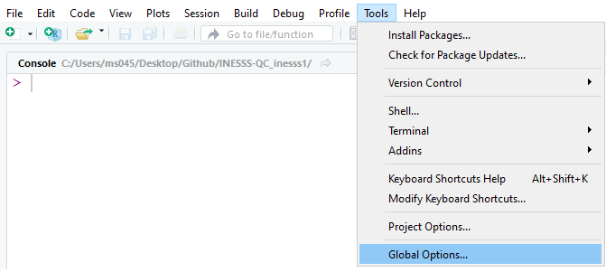

- À la section *R version:*, cliquer sur *Change…*, *Choose a specific version of R:*, puis sélectionner la version *[64-bit] R-4.0.5*. Cliquer sur *OK*.

[figure not shown]

- Toujours dans les options *General* :

[figure not shown]

  - *Save workspace to .RData on exit:*, choisir *Never*.
  - Décocher *Always save history (even when not saving .RData)*.
- Dans la section *Code*, puis *Saving*, sélectionner *UTF-8* pour le *Default text encoding:*.

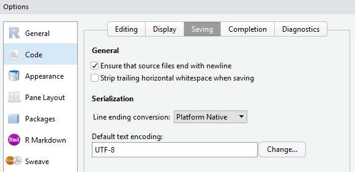

- Redémarrer RStudio pour conserver ces paramètres.
- Si les paramètres n’ont pas été sauvegardés, supprimer le dossier *RStudio-Desktop* au répertoire `C:\Users\msXXX\AppData\Local` où *msXXX* est votre numéro d’identifiant. Répéter les étapes à partir de *Cliquer sur Tools*.

## Désinstallation de R

Suivre les étapes suivantes pour supprimer une ancienne version de R installée à partir de la section 1 *Installation de R*.

- Ouvrir le dossier contenant la version de R.  
  Généralement situé au répertoire `C:\Users\msXXX\Documents\R\R-4.0.5` où *msXXX* est le numéro d’identifiant et *R-4.0.5* doit être remplacé par le numéro de version à désinstaller.
- Cliquer sur le fichier *unins000.exe*.
- Cliquer sur *Oui* pour désinstaller complètement R ainsi que tous ses composants.
- La désinstallation s’effectue, puis cliquer sur *OK* pour faire disparaître le message indiquant que R a été correctement désinstallé.
- *Facultatif* : Le dossier *R-4.0.5*, ou autre numéro de version, est toujours existant et contient toutes les librairies qui avaient été installées. Pour sauver de l’espace disque, il est conseillé de supprimer ce dossier (clic droit de la souris, puis supprimer).

## Rtools40

- Télécharger *Rtools40* en cliquant [ici](https://cran.r-project.org/bin/windows/Rtools/rtools40-x86_64.exe).
- Ouvrir le fichier téléchargé.
- Conserver les paramètres par défaut en cliquant sur *Next* à chaque étape, puis sur *Install*.
- Cliquer sur *Finish* une fois l’installation terminée.